# [Chapter 12] Predicting sale price in Ames using CART and RF

[DSLC stages]: Analysis

The following code sets up the libraries and creates cleaned and pre-processed training, validation and test data that we will use in this document.

```r
# loading libraries
library(tidyverse)
library(janitor)
library(lubridate)
library(yardstick)
library(scales)
library(patchwork)
library(fastDummies)
library(rpart)
library(glmnet)
library(ranger)
# cleaning and pre-processing the Ames data
source("functions/prepareAmesData.R")
source("functions/predStabilityPlot.R")
# list all objects (and custom functions) that exist in our environment
ls()
```

```
 [1] "ames"                    "ames_orig"
 [3] "ames_test"               "ames_test_clean"
 [5] "ames_test_preprocessed"  "ames_train"
 [7] "ames_train_clean"        "ames_train_preprocessed"
 [9] "ames_val"                "ames_val_clean"
[11] "ames_val_preprocessed"   "cleanAmesData"
[13] "predStabilityPlot"       "preProcessAmesData"
[15] "split_date"              "train_neighborhoods"
```

Since CART and RF can both use categorical features directly, let’s create a version of the Ames data with the original categorical variables (i.e., without dummy variables) that we can use in this document.

```r
ames_train_preprocessed_cat <-
  preProcessAmesData(ames_train_clean,
                     neighborhood_dummy = FALSE,
                     convert_categorical = "none")
ames_val_preprocessed_cat <-
  preProcessAmesData(ames_val_clean,
                     neighborhood_dummy = FALSE,
                     convert_categorical = "none",
                     column_selection = colnames(ames_train_preprocessed_cat),
                     neighborhood_levels = levels(ames_train_preprocessed_cat$neighborhood))
```

## 1 A manual CART demonstration

In this section, we will demonstrate one example of manually compute the first CART split for a small sample of 30 training houses.

First, let’s create the sample of 30 training houses.

```r
set.seed(3321)
ames_train_sample <- ames_train_preprocessed_cat %>%
  filter(neighborhood %in% c("NAmes", "OldTown", "CollgCr")) %>%
  select(gr_liv_area, neighborhood, sale_price) %>%
  sample_n(30)
ames_train_sample
```

```
# A tibble: 30 × 3
   gr_liv_area neighborhood sale_price
         <int> <fct>             <int>
 1        1440 NAmes            185000
 2         968 OldTown          104500
 3        1236 NAmes            134450
 4        1416 OldTown          156500
 5         952 NAmes            135750
 6         999 NAmes            178400
 7        1710 CollgCr          208500
 8        1416 OldTown          153900
 9        1873 CollgCr          235500
10        1025 CollgCr          153500
# ℹ 20 more rows
```

Then, we can create a tibble with the set of potential split questions (each defined based on a variable and a threshold or value) we will consider for this small example:

```r
ames_questions <- tribble(~variable, ~value,
                          "gr_liv_area", "1625",
                          "gr_liv_area", "1428",
                          "gr_liv_area", "905",
                          "neighborhood", "NAmes",
                          "neighborhood", "CollgCr")
```

And define a function for computing the variance split measure for each split option.

```r
getSplitVar <- function(variable, value) {
  # identify which observations answer "yes" to the split question
  if (variable == "gr_liv_area") {
    yes <- ames_train_sample[[variable]] < parse_number(value)
  } else if (variable == "neighborhood") {
    yes <- ames_train_sample[[variable]] == value
  }
  # compute the variance of the responses for the observations that answer "yes"
  var_yes <- var(ames_train_sample$sale_price[yes])
  # compute the variance of the responses for the observations that answer "no"
  var_no <- var(ames_train_sample$sale_price[!yes])
  # compute a weighted sum of the two variances
  var_split <- (sum(yes) / nrow(ames_train_sample)) * var_yes + (sum(!yes) / nrow(ames_train_sample)) * var_no

  # create a nice character string describing of the current split question
  if (variable == "gr_liv_area") {
    split_rule <- paste0(variable, " < ", value)
  } else if (variable == "neighborhood") {
    split_rule <- paste0(variable, " = ", value)
  }
  # return the results
  return(tibble(split = split_rule,
                `variance measure` = round(var_split)))
}
```

Then we can apply this function to the set of potential split questions

```r
map2_df(ames_questions$variable, ames_questions$value,
        function(.x, .y) getSplitVar(.x, .y))
```

```
# A tibble: 5 × 2
  split                  `variance measure`
  <chr>                               <dbl>
1 gr_liv_area < 1625             1343422176
2 gr_liv_area < 1428              808915591
3 gr_liv_area < 905              1255484629
4 neighborhood = NAmes           1982880348
5 neighborhood = CollgCr          832579146
```

and we see that the split question, `gr_liv_area < 1428` yields the lowest variance for these 30 training houses, and so this is the threshold rule that we will use to define the first split.

Fortunately, you wouldn’t have to do this manually yourself, since the `rpart()` function will do it for you (although it will consider a much broader range of split options than the set that we considered above). Below, you can see that the `rpart()` function similarly identifies `gr_liv_area < 1428` as the best split option.

```r
ames_example_cart <- rpart(sale_price ~ gr_liv_area, ames_train_sample)
ames_example_cart
```

```
n= 30

node), split, n, deviance, yval
      * denotes terminal node

1) root 30 59271600000 162193.7
  2) gr_liv_area< 1428 18 14281900000 133672.2 *
  3) gr_liv_area>=1428 12  8383334000 204975.9 *
```

## 2 Fitting CART and RF using the entire training set

Below, we fit a CART algorithm using the entire training dataset using all of the available features.

```r
cart <- rpart(sale_price ~ ., ames_train_preprocessed_cat)
```

We can also fit a RF algorithm using the entire training dataset and all available features using the `ranger()` function from the ranger R package.

```r
set.seed(2783)
rf <- ranger(sale_price ~ .,
             ames_train_preprocessed_cat)
```

## 3 RF variable importance

To extract the variable importance from the RF fit, you actually need to specify an `importance` argument when you train the RF algorithm.

The code below retrains the RF algorithm to extract the permutation and the impurity importance measures.

```r
set.seed(2783)
rf_permutation <- ranger(sale_price ~ .,
                         ames_train_preprocessed_cat,
                         importance = "permutation")
set.seed(2783)
rf_impurity <- ranger(sale_price ~ .,
                      ames_train_preprocessed_cat,
                      importance = "impurity")
```

Then the importance measure values for each variable can be extracted directly from the rf objects:

```r
rf_permutation$variable.importance
```

```
           ms_zoning         lot_frontage             lot_area
            29990233             43328750            112572743
           lot_shape         neighborhood          house_style
            15397838             64434276             22335099
        overall_qual         overall_cond           year_built
           757602360             27453696            233408619
      year_remod_add         mas_vnr_area           exter_qual
           164184380             65445022            218672011
           bsmt_qual        bsmt_exposure      bsmt_fin_type_1
           102747436             38685163             30460596
       total_bsmt_sf           heating_qc          gr_liv_area
           318492713             23935696            829170539
      bedroom_abv_gr         kitchen_qual      tot_rms_abv_grd
            28067302             65345225             60339708
          fireplaces         fireplace_qu        garage_yr_blt
           116851441             89418815            204093298
       garage_finish          garage_cars          garage_area
            50015361            156404585            206416385
        wood_deck_sf              mo_sold              yr_sold
            11561075             -1463629             -3529072
masonry_veneer_brick    foundation_cinder  foundation_concrete
             6233974              9750669             39234530
     garage_attached           lot_inside       exterior_vinyl
            52169552             -1289302             23747205
           bathrooms                porch
           297241143              3778602
```

```r
rf_impurity$variable.importance
```

```
           ms_zoning         lot_frontage             lot_area
         21975764061          92986738627         167644415520
           lot_shape         neighborhood          house_style
         12360419409          50178406572          15321338127
        overall_qual         overall_cond           year_built
        869643445312          31488917647         248978055848
      year_remod_add         mas_vnr_area           exter_qual
        121833580568         181228042950         272813499352
           bsmt_qual        bsmt_exposure      bsmt_fin_type_1
        162270048928          42168374363          31743500320
       total_bsmt_sf           heating_qc          gr_liv_area
        411190976945          20789088419         808332243684
      bedroom_abv_gr         kitchen_qual      tot_rms_abv_grd
         37096725605          92437872265         113391438951
          fireplaces         fireplace_qu        garage_yr_blt
        133561623301          86546151771         178850229484
       garage_finish          garage_cars          garage_area
         50504838006         270165707631         305775266496
        wood_deck_sf              mo_sold              yr_sold
         53231992951          22753565156          11376990565
masonry_veneer_brick    foundation_cinder  foundation_concrete
          8166164256           5188988900          38118096397
     garage_attached           lot_inside       exterior_vinyl
         49009357077           6069737122          15870730263
           bathrooms                porch
        445588813672           5486085185
```

And we can visualize these importance measures using a bar plot:

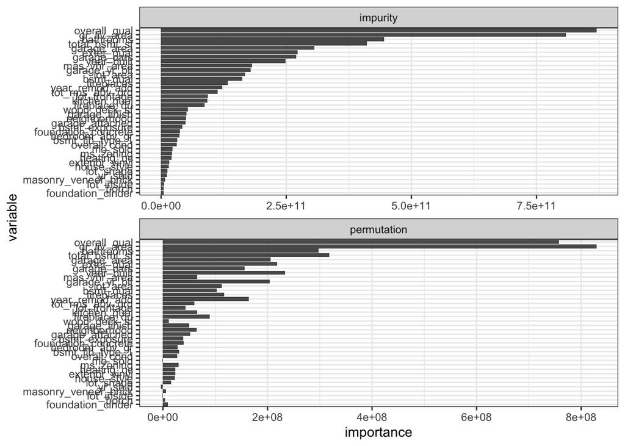

```r
# put the two importance measures in a tibble
tibble(variable = names(rf_permutation$variable.importance),
       permutation = rf_permutation$variable.importance,
       impurity = rf_impurity$variable.importance) |>
  # arrange in order of the impurity measure
  arrange(impurity) |>
  # ensure that the variable names will appear in the correct order by fixing the factor level order
  mutate(variable = fct_inorder(variable)) |>
  # convert to a longer format so we can use facet_wrap
  pivot_longer(c("permutation", "impurity"),
               names_to = "measure",
               values_to = "importance") |>
  ggplot() +
  # create bar plot
  geom_col(aes(x = variable, y = importance)) +
  # create a separate plot for each measure
  facet_wrap(~measure, ncol = 1, scales = "free") +
  # switch the x- and y-axes
  coord_flip() +
  theme_bw()
```

## 4 A PCS evaluation of the CART and RF fits

And we can then evaluate the predictability and stability of this CART fit!

### 4.1 Predictability

Let’s evaluate the CART fit using the validation set. This will involve generating validation set predictions, which we can then compare to the original LS (all) fit.

First, let’s create a version of the original LS fit

```r
ls_all <- lm(sale_price ~ ., ames_train_preprocessed)
```

Then we can put both our CART and LS predictions into a data frame (tibble).

```r
val_performance <-
  tibble(pid = ames_val_preprocessed$pid,
         true = ames_val_preprocessed$sale_price,
         pred_ls_all = predict(ls_all, ames_val_preprocessed),
         pred_cart = predict(cart, ames_val_preprocessed_cat),
         pred_rf = predict(rf, ames_val_preprocessed_cat)$prediction)
```

And we can evaluate the performance of each fit, and format the results in the table below:

```r
val_performance |>
  pivot_longer(c("pred_ls_all", "pred_cart", "pred_rf"),
               names_to = "fit", values_to = "pred", names_prefix = "pred_") |>
  group_by(fit) |>
  summarise(rmse = rmse_vec(true, pred),
            mae = mae_vec(true, pred),
            cor = cor(true, pred)) |>
  arrange(cor)
```

```
# A tibble: 3 × 4
  fit      rmse    mae   cor
  <chr>   <dbl>  <dbl> <dbl>
1 cart   38881. 28105. 0.827
2 ls_all 23267. 17332. 0.942
3 rf     19735. 14046. 0.960
```

Notice from the table above that the CART algorithm is *worse* across all measures than the LS fit.

### 4.2 Stability to data perturbations

To assess the stability of our data to appropriate perturbations in the data, we first need to decide what makes an “appropriate” perturbation. That is, what type of data perturbation (e.g., adding random noise, or performing subsampling) most resembles the way that the data *could* have been measured or collected differently, as well as how these results will be applied in the future.

While the Ames housing data does not correspond to a random sample from a greater population of houses, each house is more-or-less exchangeable, meaning that a random sampling technique would be a reasonable perturbation, so we will draw 100 bootstrap samples of the original data.

Moreover, it is plausible that the living area measurements involve a slight amount of measurement error, although we do not have a realistic sense of how much. To really stress-test our results, we choose to add another perturbation to the data that involves adding some random noise to 30% of the `gr_liv_area` measurements. Since the standard deviation of the living area is approximately 500, we decide to add or subtract a random number between 0 and 250 (i.e. add noise up to half a standard deviation) to 30% of `gr_liv_area` observations.

Since we will be repeating this analysis many times, we will write a function that will take an Ames dataset, and return a perturbed version of it.

```r
perturbAmes <- function(.ames_data,
                        .perturb_gr_liv_area = FALSE) {
  perturbed_ames <- .ames_data |>
    # create a binary variable that indicates which 30% of the area values to perturb
    mutate(perturb_area = rbernoulli(n(), p = 0.3) * .perturb_gr_liv_area) |>
    # conduct a bootstrap sample
    sample_frac(1, replace = TRUE) |>
    rowwise() |>
    # perturb the gr_liv_area variable
    mutate(gr_liv_area = if_else(perturb_area == 1 & .perturb_gr_liv_area,
                                 # add some number between -250 and 250
                                 gr_liv_area + as.integer(round(runif(1, -250, 250))),
                                 # or else, do not perturb the living area
                                 gr_liv_area)) |>
    # undo rowwise()
    ungroup() |>
    # remove unnecessary binary variable
    select(-perturb_area)
  return(perturbed_ames)
}
```

Below we create a tibble with a list column containing the 100 perturbed versions of the training data.

```r
set.seed(467824)
ames_data_perturbed <- tibble(iter = 1:100) |>
  rowwise() |>
  mutate(data_train_perturbed = list(perturbAmes(ames_train_preprocessed,
                                                 .perturb_gr_liv_area = TRUE)))
set.seed(467824)
# add a version with the categorical variables
# (use the same seed as above to ensure that the perturbations are the same)
ames_data_perturbed <- ames_data_perturbed |>
  mutate(data_train_perturbed_cat = list(perturbAmes(ames_train_preprocessed_cat,
                                                     .perturb_gr_liv_area = TRUE))) |>
  ungroup()

# look at the object
ames_data_perturbed
```

```
# A tibble: 100 × 3
    iter data_train_perturbed  data_train_perturbed_cat
   <int> <list>                <list>
 1     1 <tibble [1,126 × 48]> <tibble [1,126 × 39]>
 2     2 <tibble [1,126 × 48]> <tibble [1,126 × 39]>
 3     3 <tibble [1,126 × 48]> <tibble [1,126 × 39]>
 4     4 <tibble [1,126 × 48]> <tibble [1,126 × 39]>
 5     5 <tibble [1,126 × 48]> <tibble [1,126 × 39]>
 6     6 <tibble [1,126 × 48]> <tibble [1,126 × 39]>
 7     7 <tibble [1,126 × 48]> <tibble [1,126 × 39]>
 8     8 <tibble [1,126 × 48]> <tibble [1,126 × 39]>
 9     9 <tibble [1,126 × 48]> <tibble [1,126 × 39]>
10    10 <tibble [1,126 × 48]> <tibble [1,126 × 39]>
# ℹ 90 more rows
```

Then we can define a tibble that has a list column containing each relevant LS fits in it:

```r
set.seed(287394)
perturbed_data_rf <- ames_data_perturbed |>
  rowwise() |>
  mutate(ls_all = list(lm(sale_price ~ ., data_train_perturbed)),
         cart = list(rpart(sale_price ~ ., data_train_perturbed_cat)),
         rf = list(ranger(sale_price ~ ., data_train_perturbed_cat))) |>
  ungroup()
perturbed_data_rf
```

```
# A tibble: 100 × 6
    iter data_train_perturbed  data_train_perturbed_cat ls_all cart    rf
   <int> <list>                <list>                   <list> <list>  <list>
 1     1 <tibble [1,126 × 48]> <tibble [1,126 × 39]>    <lm>   <rpart> <ranger>
 2     2 <tibble [1,126 × 48]> <tibble [1,126 × 39]>    <lm>   <rpart> <ranger>
 3     3 <tibble [1,126 × 48]> <tibble [1,126 × 39]>    <lm>   <rpart> <ranger>
 4     4 <tibble [1,126 × 48]> <tibble [1,126 × 39]>    <lm>   <rpart> <ranger>
 5     5 <tibble [1,126 × 48]> <tibble [1,126 × 39]>    <lm>   <rpart> <ranger>
 6     6 <tibble [1,126 × 48]> <tibble [1,126 × 39]>    <lm>   <rpart> <ranger>
 7     7 <tibble [1,126 × 48]> <tibble [1,126 × 39]>    <lm>   <rpart> <ranger>
 8     8 <tibble [1,126 × 48]> <tibble [1,126 × 39]>    <lm>   <rpart> <ranger>
 9     9 <tibble [1,126 × 48]> <tibble [1,126 × 39]>    <lm>   <rpart> <ranger>
10    10 <tibble [1,126 × 48]> <tibble [1,126 × 39]>    <lm>   <rpart> <ranger>
# ℹ 90 more rows
```

We can then generate sale price predictions for each house in the validation set using each perturbed LS fits.

```r
perturbed_data_pred <- perturbed_data_rf |>
  rowwise() |>
  transmute(iter,
            true_val = list(ames_val_preprocessed_cat$sale_price),
            pred_val_ls_all = list(predict(ls_all, ames_val_preprocessed)),
            pred_val_cart = list(predict(cart, ames_val_preprocessed_cat)),
            pred_val_rf = list(predict(rf, ames_val_preprocessed_cat)$predictions)) |>
  ungroup() |>
  # add pid for filtering to a common 150 validation set houses
  mutate(pid = list(ames_val_preprocessed$pid)) |>
  # unnest the tibble
  unnest(c(true_val, pid,
           pred_val_ls_all, pred_val_cart, pred_val_rf))
perturbed_data_pred
```

```
# A tibble: 63,600 × 6
    iter true_val pred_val_ls_all pred_val_cart pred_val_rf       pid
   <int>    <int>           <dbl>         <dbl>       <dbl>     <int>
 1     1   155000         221463.       185136.     180950. 527226040
 2     1   178000         193809.       167200.     206969. 916460020
 3     1   254750         251411.       251760.     247409. 907252060
 4     1   230000         249480.       131996.     220294. 534151120
 5     1   146500         148890.       131996.     154647. 902406070
 6     1   124000         101344.       131996.     122130. 907200230
 7     1   159900         174802.       185136.     150121. 904301100
 8     1   153000         189939.       167200.     165156. 534476260
 9     1   269500         269970.       241597.     303233. 906230010
10     1   195000         221381.       185136.     207160. 916460060
# ℹ 63,590 more rows
```

Let’s use the prediction stability plot function to visualize the range of perturbed predictions for 150 validation set houses for each fit.

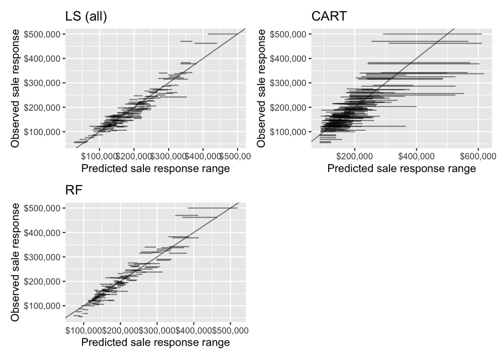

```r
set.seed(8674)
val_sample_pid <- sample(ames_val_preprocessed$pid, 150)


gg_stability_data_ls_all <- perturbed_data_pred |>
  filter(pid %in% val_sample_pid) |>
  predStabilityPlot(.true_var = true_val, .pred_var = pred_val_ls_all,
                    .title = "LS (all)")

gg_stability_data_cart <- perturbed_data_pred |>
  filter(pid %in% val_sample_pid) |>
  predStabilityPlot(.true_var = true_val, .pred_var = pred_val_cart,
                    .title = "CART")


gg_stability_data_rf <- perturbed_data_pred |>
  filter(pid %in% val_sample_pid) |>
  predStabilityPlot(.true_var = true_val, .pred_var = pred_val_rf,
                    .title = "RF")


gg_stability_data_ls_all + gg_stability_data_cart +
  gg_stability_data_rf +
  plot_layout(ncol = 2)
```

Clearly the CART algorithm is much *less* stable than the LS or RF algorithms, but the RF algorithm looks to have similar stability to the LS algorithm.

The table below shows the average length of the intervals for each algorithm, which actually reveals that the RF algorithm is slightly more stable than the LS algorithm.

```r
perturbed_data_pred |>
  pivot_longer(c("pred_val_ls_all", "pred_val_cart", "pred_val_rf"),
               names_to = "fit", values_to = "pred_val",
               names_prefix = "pred_val_") |>
  # for each house
  group_by(pid, fit) |>
  # compute the max-min
  summarise(sd = sd(pred_val)) |>
  ungroup() |>
  group_by(fit) |>
  summarise(mean_sd = mean(sd))
```

[output not shown]

```
# A tibble: 3 × 2
  fit    mean_sd
  <chr>    <dbl>
1 cart    19449.
2 ls_all   5827.
3 rf       3970.
```

Note that these numbers might be slightly different to the numbers reported in the book, but they should be in the same ballpark.

We can also investigate the distribution of the correlation performance across the data perturbations for each model. From the boxplots below, it is clear that the distribution of the correlation performance measure for the CART algorithm is much less stable to the data perturbations than for the LS and RF algorithms.

[output not shown]

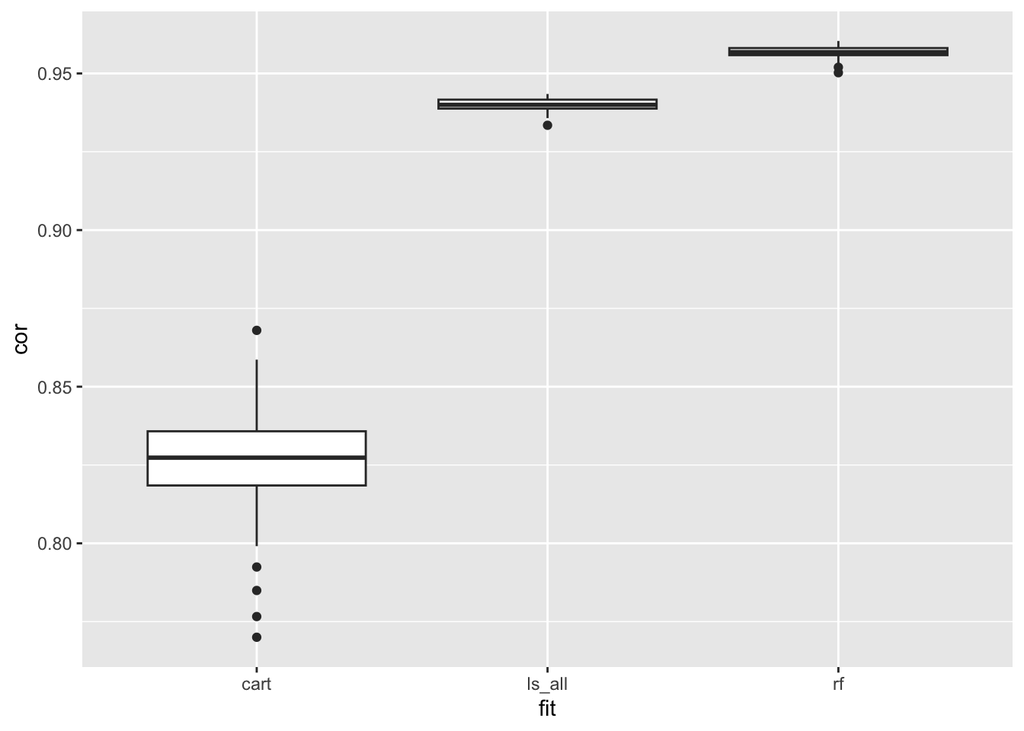

```r
perturbed_data_pred |>
  pivot_longer(c(pred_val_ls_all, pred_val_cart, pred_val_rf),
               names_to = "fit", names_prefix = "pred_val_",
               values_to = "pred") |>
  group_by(fit, iter) |>
  summarise(cor = cor(true_val, pred)) |>
  ggplot() +
  geom_boxplot(aes(x = fit, y = cor))
```

### 4.3 Stability to judgment call perturbations

Next, we can compare the stability of each algorithm to the pre-processing judgment calls.

```r
# create the judgment call perturbation combinations
param_options <- expand_grid(max_identical_thresh = c(0.65, 0.8, 0.95),
                             n_neighborhoods = c(10, 20),
                             impute_missing_categorical = c("other", "mode"),
                             simplify_vars = c(TRUE, FALSE),
                             transform_response = c("none", "log", "sqrt"),
                             cor_feature_selection_threshold = c(0, 0.5),
                             convert_categorical = c("numeric", "simplified_dummy", "dummy"))

param_options |> print(width = Inf)
```

```
# A tibble: 432 × 7
   max_identical_thresh n_neighborhoods impute_missing_categorical simplify_vars
                  <dbl>           <dbl> <chr>                      <lgl>
 1                 0.65              10 other                      TRUE
 2                 0.65              10 other                      TRUE
 3                 0.65              10 other                      TRUE
 4                 0.65              10 other                      TRUE
 5                 0.65              10 other                      TRUE
 6                 0.65              10 other                      TRUE
 7                 0.65              10 other                      TRUE
 8                 0.65              10 other                      TRUE
 9                 0.65              10 other                      TRUE
10                 0.65              10 other                      TRUE
   transform_response cor_feature_selection_threshold convert_categorical
   <chr>                                        <dbl> <chr>
 1 none                                           0   numeric
 2 none                                           0   simplified_dummy
 3 none                                           0   dummy
 4 none                                           0.5 numeric
 5 none                                           0.5 simplified_dummy
 6 none                                           0.5 dummy
 7 log                                            0   numeric
 8 log                                            0   simplified_dummy
 9 log                                            0   dummy
10 log                                            0.5 numeric
# ℹ 422 more rows
```

Then we need to create a cleaned/pre-processed version of the training and validation datasets for each combination of these judgment calls by adding list columns to the `param_options` tibble:

```r
# create the perturbed datasets in a list column
ames_jc_perturbed <- param_options |>
  rowwise() |>
  # add training data list column
  mutate(data_train_perturbed =
           list(preProcessAmesData(ames_train_clean,
                                   max_identical_thresh = max_identical_thresh,
                                   n_neighborhoods = n_neighborhoods,
                                   impute_missing_categorical = impute_missing_categorical,
                                   simplify_vars = simplify_vars,
                                   transform_response = transform_response,
                                   cor_feature_selection_threshold = cor_feature_selection_threshold,
                                   convert_categorical = convert_categorical))) |>
  # add validation data list column
  mutate(data_val_perturbed =
           list(preProcessAmesData(ames_val_clean,
                                   max_identical_thresh = max_identical_thresh,
                                   n_neighborhoods = n_neighborhoods,
                                   # make sure the validation neighborhoods match the training neighborhoods
                                   neighborhood_levels = map_chr(str_split(colnames(select(data_train_perturbed, contains("neighborhood"))), "neighborhood_"), ~.[2]),
                                   impute_missing_categorical = impute_missing_categorical,
                                   simplify_vars = simplify_vars,
                                   transform_response = transform_response,
                                   cor_feature_selection_threshold = cor_feature_selection_threshold,
                                   convert_categorical = convert_categorical,
                                   # make sure validation set cols match the training set cols
                                   column_selection = colnames(data_train_perturbed),
                                   keep_pid = TRUE)))

# look at the object we just created
ames_jc_perturbed |> print(width = Inf)
```

```
# A tibble: 432 × 9
# Rowwise:
   max_identical_thresh n_neighborhoods impute_missing_categorical simplify_vars
                  <dbl>           <dbl> <chr>                      <lgl>
 1                 0.65              10 other                      TRUE
 2                 0.65              10 other                      TRUE
 3                 0.65              10 other                      TRUE
 4                 0.65              10 other                      TRUE
 5                 0.65              10 other                      TRUE
 6                 0.65              10 other                      TRUE
 7                 0.65              10 other                      TRUE
 8                 0.65              10 other                      TRUE
 9                 0.65              10 other                      TRUE
10                 0.65              10 other                      TRUE
   transform_response cor_feature_selection_threshold convert_categorical
```

[output cut: 24 more lines]

```r
perturbed_jc_pred <- ames_jc_perturbed |>
  rowwise() |>
  # generate the LS (all) fit
  mutate(ls_all = list(lm(sale_price ~ ., data_train_perturbed)),
         cart = list(rpart(sale_price ~ ., data_train_perturbed)),
         rf = list(ranger(sale_price ~ ., data_train_perturbed))) |>
  mutate(pid = list(data_val_perturbed$pid),
         true_val = list(data_val_perturbed$sale_price),
         pred_val_ls_all = list(predict(ls_all, data_val_perturbed)),
         pred_val_cart = list(predict(cart, data_val_perturbed)),
         pred_val_rf = list(predict(rf, data_val_perturbed)$predictions)) |>
  # if the perturbation involved a response transformation, we need to undo
  # the transformation for the predictions so that they are comparable with
  # the untransformed versions
  mutate(pred_val_ls_all =
           case_when(transform_response == "log" ~ list(exp(pred_val_ls_all)),
                     transform_response == "sqrt" ~ list(pred_val_ls_all^2),
                     transform_response == "none" ~ list(pred_val_ls_all))) |>
  mutate(pred_val_cart =
           case_when(transform_response == "log" ~ list(exp(pred_val_cart)),
                     transform_response == "sqrt" ~ list(pred_val_cart^2),
                     transform_response == "none" ~ list(pred_val_cart))) |>
  mutate(pred_val_rf =
           case_when(transform_response == "log" ~ list(exp(pred_val_rf)),
                     transform_response == "sqrt" ~ list(pred_val_rf^2),
                     transform_response == "none" ~ list(pred_val_rf))) |>
  mutate(true_val =
           case_when(transform_response == "log" ~ list(exp(true_val)),
                     transform_response == "sqrt" ~ list(true_val^2),
                     transform_response == "none" ~ list(true_val))) |>
  # remove columns we won't need anymore
  select(-ls_all, -cart, -rf, -data_train_perturbed, -data_val_perturbed) |>
  ungroup() |>
  # unnest the tibble
  unnest(c(pid, true_val,
           pred_val_ls_all, pred_val_cart, pred_val_rf))

# look at the object we've created
perturbed_jc_pred |> print(width = Inf)
```

```
# A tibble: 274,752 × 12
   max_identical_thresh n_neighborhoods impute_missing_categorical simplify_vars
                  <dbl>           <dbl> <chr>                      <lgl>
 1                 0.65              10 other                      TRUE
 2                 0.65              10 other                      TRUE
 3                 0.65              10 other                      TRUE
 4                 0.65              10 other                      TRUE
 5                 0.65              10 other                      TRUE
 6                 0.65              10 other                      TRUE
 7                 0.65              10 other                      TRUE
 8                 0.65              10 other                      TRUE
 9                 0.65              10 other                      TRUE
10                 0.65              10 other                      TRUE
   transform_response cor_feature_selection_threshold convert_categorical
   <chr>                                        <dbl> <chr>
```

[output cut: 23 more lines]

We next want to use it to visualize the range of perturbed predictions for 150 validation set houses for each fit. However, first, we should filter any particularly poorly performing fits. To identify whether there are any particularly poorly performing fits, let’s compute the correlation predictive performance for each fit to each perturbed dataset and visualize their distributions across the different fits and judgment calls.

```r
perturbed_jc_correlations <- perturbed_jc_pred |>
  # convert the data to long-form (create a single column for all predictions and
  # a fit/model identifier)
  pivot_longer(cols = c("pred_val_ls_all", "pred_val_cart", "pred_val_rf"),
                names_to = "fit", values_to = "pred_val",
               names_prefix = "pred_val_") |>
  group_by(fit, max_identical_thresh, n_neighborhoods,
                      simplify_vars, convert_categorical, transform_response,
                       cor_feature_selection_threshold) |>
  # compute the correlation performance for each fit
  summarise(correlation = cor(true_val, pred_val))
```

[output not shown]

```r
# look at the object
perturbed_jc_correlations |> print(width = Inf)
```

```
# A tibble: 648 × 8
# Groups:   fit, max_identical_thresh, n_neighborhoods, simplify_vars,
#   convert_categorical, transform_response [324]
   fit   max_identical_thresh n_neighborhoods simplify_vars convert_categorical
   <chr>                <dbl>           <dbl> <lgl>         <chr>
 1 cart                  0.65              10 FALSE         dummy
 2 cart                  0.65              10 FALSE         dummy
 3 cart                  0.65              10 FALSE         dummy
 4 cart                  0.65              10 FALSE         dummy
 5 cart                  0.65              10 FALSE         dummy
 6 cart                  0.65              10 FALSE         dummy
 7 cart                  0.65              10 FALSE         numeric
 8 cart                  0.65              10 FALSE         numeric
 9 cart                  0.65              10 FALSE         numeric
10 cart                  0.65              10 FALSE         numeric
   transform_response cor_feature_selection_threshold correlation
   <chr>                                        <dbl>       <dbl>
 1 log                                            0         0.830
 2 log                                            0.5       0.830
 3 none                                           0         0.842
 4 none                                           0.5       0.840
 5 sqrt                                           0         0.849
 6 sqrt                                           0.5       0.848
 7 log                                            0         0.830
 8 log                                            0.5       0.830
 9 none                                           0         0.842
10 none                                           0.5       0.840
# ℹ 638 more rows
```

Let’s visualize these correlations against each of the judgment call options for each fit:

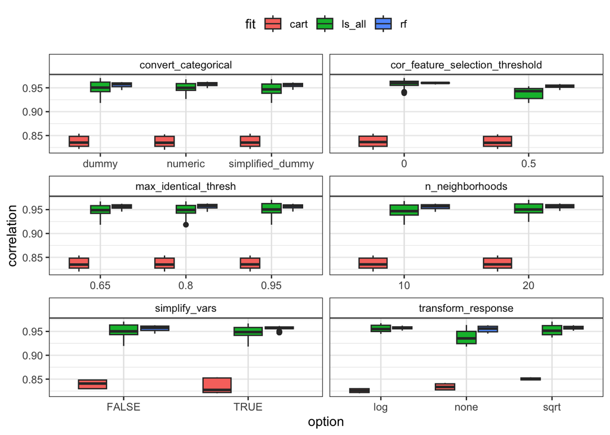

```r
perturbed_jc_correlations |>
  ungroup() |>
  # convert all judgment call options to character variables
  mutate(across(one_of("max_identical_thresh", "n_neighborhoods",
                       "simplify_vars", "convert_categorical",
                       "transform_response",
                       "cor_feature_selection_threshold"), as.character)) |>
  # create a long-form data frame with a single column for the judgment calls
  pivot_longer(cols = c("max_identical_thresh", "n_neighborhoods",
                        "simplify_vars", "convert_categorical",
                        "transform_response",
                        "cor_feature_selection_threshold"),
               names_to = "judgment_call", values_to = "option") |>
  # plot the correlations against the judgment call options for each fit
  ggplot() +
  theme_bw() +
  geom_boxplot(aes(x = option, y = correlation, fill = fit)) +
  facet_wrap(~judgment_call, scales = "free_x", ncol = 2) +
  theme(legend.position = "top",
        panel.grid.major.x = element_line(color = "grey90"),
        strip.background = element_rect(fill = "white"))
```

The CART algorithm is overall much less accurate than the other two, but none of the judgment calls seem to be affecting the accuracy all that much.

Let’s create a prediction stability plot for each fit

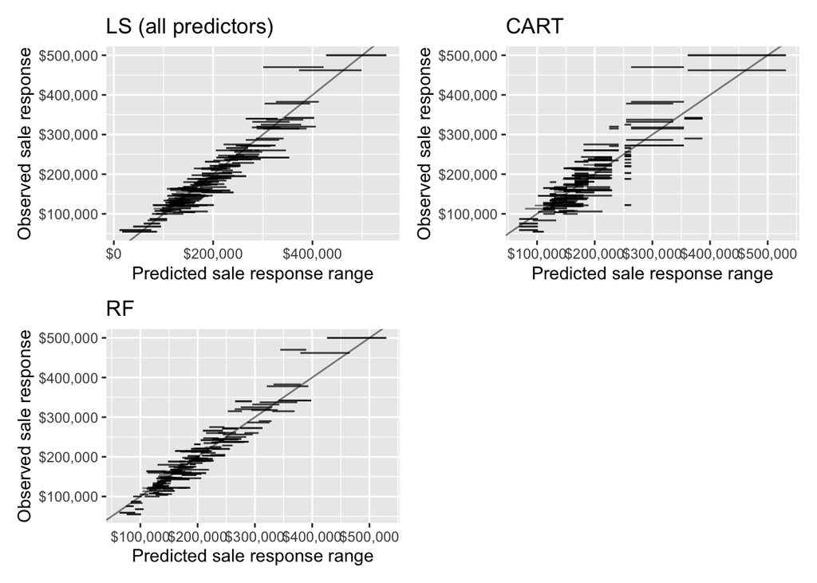

```r
gg_stability_jc_ls_all <- perturbed_jc_pred |>
  # conduct predictability screening
  left_join(filter(perturbed_jc_correlations, fit == "ls_all")) |>
  select(-fit) |>
  # filter to the 150 validation set houses
  filter(pid %in% val_sample_pid) |>
  # create the prediction stability plot
  predStabilityPlot(.true_var = true_val,
                    .pred_var = pred_val_ls_all,
                    .title = "LS (all predictors)")

gg_stability_jc_cart <- perturbed_jc_pred |>
  # conduct predictability screening
  left_join(filter(perturbed_jc_correlations, fit == "cart")) |>
  select(-fit) |>
  # filter to the 150 validation set houses
  filter(pid %in% val_sample_pid) |>
  # create the prediction stability plot
  predStabilityPlot(.true_var = true_val,
                    .pred_var = pred_val_cart,
                    .title = "CART")

gg_stability_jc_rf <- perturbed_jc_pred |>
  # conduct predictability screening
  left_join(filter(perturbed_jc_correlations, fit == "rf")) |>
  select(-fit) |>
  # filter to the 150 validation set houses
  filter(pid %in% val_sample_pid) |>
  # create the prediction stability plot
  predStabilityPlot(.true_var = true_val,
                    .pred_var = pred_val_rf,
                    .title = "RF")

gg_stability_jc_ls_all + gg_stability_jc_cart +
  gg_stability_jc_rf + plot_spacer() +
  plot_layout(ncol = 2)
```

The average SD of the perturbed predictions for each algorithm is shown below:

```r
perturbed_jc_pred |>
  pivot_longer(c("pred_val_ls_all", "pred_val_cart", "pred_val_rf"),
               names_to = "fit", values_to = "pred_val",
               names_prefix = "pred_val_") |>
  # for each house
  group_by(pid, fit) |>
  # compute the max-min
  summarise(sd = sd(pred_val)) |>
  ungroup() |>
  group_by(fit) |>
  summarise(mean_sd = mean(sd))
```

[output not shown]

```
# A tibble: 3 × 2
  fit    mean_sd
  <chr>    <dbl>
1 cart    11781.
2 ls_all   9360.
3 rf       5238.
```

Note that these numbers might be slightly different to the numbers reported in the book, but again, they should be in the same ballpark.

Lastly, we can also investigate the distribution of the correlation performance across the cleaning/pre-processing judgment call perturbations for each model. From the boxplots below, this time it seems as though the RF fit yields much more stable correlation performance measure values than the LS and RF algorithms.

[output not shown]

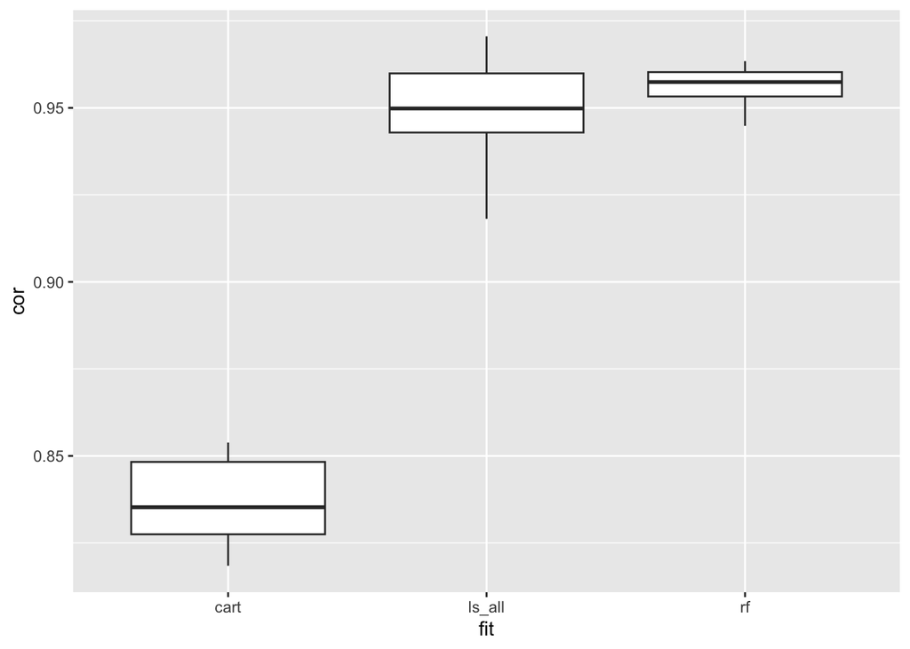

```r
perturbed_jc_pred |>
  pivot_longer(c(pred_val_ls_all, pred_val_cart, pred_val_rf),
               names_to = "fit", names_prefix = "pred_val_",
               values_to = "pred") |>
  group_by(fit,
           # judgment call options
           max_identical_thresh, n_neighborhoods,
           impute_missing_categorical, simplify_vars,
           transform_response, cor_feature_selection_threshold,
           convert_categorical) |>
  summarise(cor = cor(true_val, pred)) |>
  ggplot() +
  geom_boxplot(aes(x = fit, y = cor))
```